# 6 Resampling method

Resampling은 통계학 및 통계적 학습에서 자주 사용되는 기법으로, **주어진 훈련 데이터로부터 새로운 샘플을 반복적으로 생성**함으로써 적합된 모형에 대해 **추가적인 정보를 얻을 수 있는 방법**이다.

Resampling 기법은 크게 다음 두 가지로 나눌 수 있다:

- **Cross-validation**
- **Bootstrap**

이 두 방법은 서로 목적이 다르지만, 모형 평가 및 추정 정확도 향상에 있어 매우 유용하게 사용된다.

- **Cross-validation**은 테스트 오류를 추정하고, 모형의 일반화 성능을 비교하거나 모형의 적절한 복잡도(flexibility)를 선택하는 데 활용된다.
- **Bootstrap**은 주어진 데이터로부터 반복 샘플을 생성하여 **모수 추정치의 분산(또는 표준 오차)** 등을 평가할 수 있게 해준다.

### 6.0.1 Validation set approach review

Validation set approach는 앞 단원에서 이미 살펴 보았다.

기계 학습에서는 **training error**와 **test error**를 명확히 구분하는 것이 중요하다.

- **Training error**는 모델을 학습시킨 데이터에서의 오차이고,
- **Test error**는 모델이 **보지 않은 새로운 데이터**에 대해 발생시키는 오차의 평균으로, 일반화 성능을 평가하는 핵심 지표이다.

테스트 에러가 작은 모형이 좋은 모형이며, 이를 확인하기 위해 정확한 테스트 에러 추정이 필요하다.

그러나 이상적인 상황처럼 충분히 큰 테스트 데이터셋을 별도로 확보하여 완벽한 테스트 에러를 측정하는 것은 어려운 경우가 많다.

따라서, 전체 데이터를 나누어 일부는 훈련(training)에, 나머지는 검증(validation)에 사용하는 방법이 널리 쓰인다.

- 가장 간단한 방법은 데이터 셋을 랜덤으로 나누어 하나는 훈련에 다른 하나는 테스트 에러 추정에 사용하는 것이다.
- 이 때 테스트 용으로 남겨둔 데이터를 validation set 혹은 hold-out set이라고도 한다.

트레이닝 셋을 이용하여 모델을 적합하고, validation set을 이용하여 테스트 에러를 추정한다.

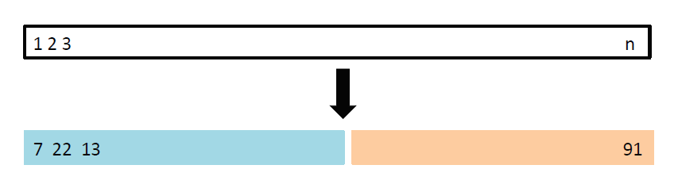

Validation set에 어떤 데이터가 속하는지는 무작위(random)로 결정되기 때문에, 이 랜덤성에 따라 테스트 오차(test error)에 대한 추정치는 크게 달라질 수 있다.

또한, 이 방법에서는 전체 데이터 중 일부만을 훈련(training)에 사용하므로, 전체 데이터를 사용할 때보다 모형 적합(fitting)의 정확도가 떨어질 수 있다.

따라서, validation set을 기반으로 한 테스트 오차 추정치는 실제 테스트 오차보다 과대 추정(overestimate)될 가능성이 있다.

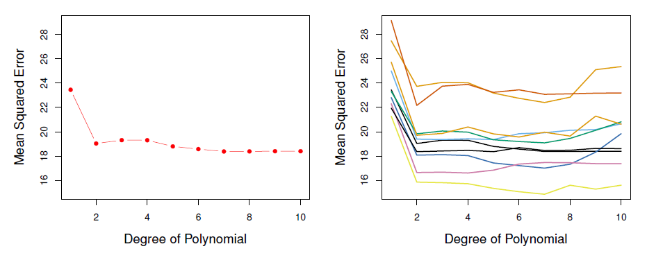

위 그림에서 왼쪽은 하나의 validation set으로 validation error를 모형의 차수에 따라 나타낸 것이다.

오른쪽은 이 방법을 서로 다른 validation set들에 반복 적용하여 얻은 것으로, 각각이 서로 다른 실험에서 얻은 validation error를 나타낸다.

- Validation error 자체의 변화량이 큰 것을 관찰할 수 있다.

#### 6.0.1.1 Validation set

특별히 모델 하이퍼파라미터 튜닝을 하지 않을 때에는 validation set과 test set이라는 용어를 혼용해서 사용하곤 한다.

- 앞 단원에서는 validation set을 test set이라고 불렀고, scikit-learn 예제에서 `train_test_split` 함수를 이용해 train/test set을 나누어 실습하였다.

반면, 훈련 중 하이퍼파라미터를 조정하거나 모델을 선택하는 경우, 훈련 데이터와 별개인 validation set을 이용하여 하이퍼파라미터를 선택하고,

최종적으로 모델을 평가할 때는 훈련 데이터와 validation set이 아닌 별도의 test set을 이용하여 평가한다.

## 6.1 Cross-Validation

Cross-validation은 validation 역할을 여러 부분이 번갈아 수행한다는 점에서 교차(cross)라고 부른다.

### 6.1.1 Leave-One-Out Cross-Validation

LOOCV 방법은 앞의 validation 방법과 비슷하나 단점을 보완하였다.

비슷한 크기로 두 셋을 나누는 대신, 하나의 관찰값 $(x_1, y_1)$이 validation에 사용된다.

나머지 데이터는 트레이닝에 이용하고, 적합이 끝나면 적합된 모형을 이용해 예측값 $\hat y_1$을 계산한다.

이는 테스트 에러에 대해 unbiased지만 분산이 매우 클 것이다.

모든 데이터에 대해 위 과정을 반복하고, $\mathrm{MSE}_i$들을 계산할 수 있다.

테스트 MSE에 대한 LOOCV 추정량은 다음과 같다.

$$\mathrm{CV}_{(n)} = \frac{1}{n} \sum_{i=1}^{n} \mathrm{MSE}_{i}$$

이를 그림으로 표현하면 다음과 같다.

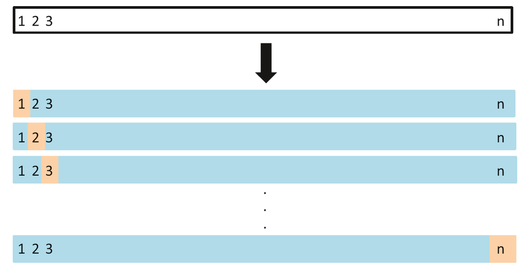

### 6.1.2 k-fold Cross-Validation

LOOCV는 많은 장점을 지녔지만, 데이터의 총 수가 많으면 상당히 오랜 시간이 걸린다.

이 경우 k-fold CV 방법은 LOOCV의 대안이 된다.

k-fold 방법에서는 데이터를 랜덤하게 $k$ 개의 그룹으로 나눈다.

이 중 한 그룹이 validation set이고 나머지는 훈련에 사용된다. 훈련이 끝난 모형으로 validation set에 대해 MSE를 측정할 수 있다.

LOOCV의 경우와 마찬가지로, 모든 $k$ 개의 그룹이 validation set이 될 수 있으며, 이 때마다 나머지 그룹들이 훈련을 담당한다.

따라서 각 그룹에 대해 MSE가 측정되면 이것의 평균으로 테스트 에러에 대한 추정치를 계산한다.

$$\mathrm{CV}_k = \frac{1}{k} \sum_{i=1}^{k} \mathrm{MSE}_i$$

아래 그림은 k-fold cross validation을 나타낸다.

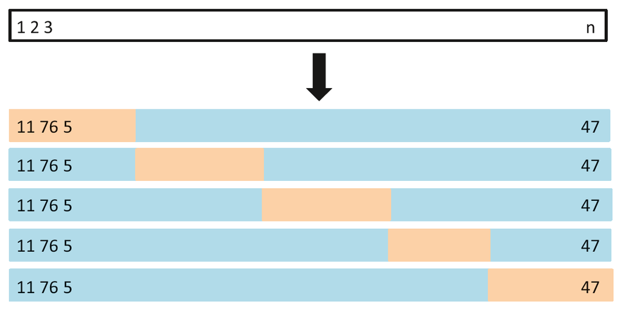

다음은 시뮬레이션 데이터를 이용하여 계산한 true test MSE와 추정된 test MSE의 비교이다.

파란색 선이 true test MSE이며, 이것에 대한 LOOCV 추정치가 검은 점선으로, 10-fold CV 추정치가 주황색으로 나타나 있다.

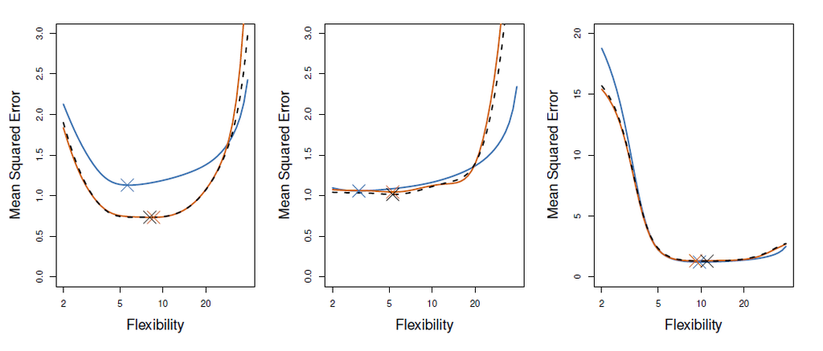

### 6.1.3 Bias-variance trade-off for k-fold cross-validation

k-fold CV는 계산 비용 측면에서 LOOCV보다 유리할 뿐 아니라, 종종 LOOCV 보다 더 정확한 test error를 계산한다.

- LOOCV는 한번에 거의 모든 데이터를 트레이닝에 사용하기 때문에, bias를 줄이는 데에 있어서는 k-fold CV 보다 우월하다.
- 반면 k-fold CV는 variance 측면에서 LOOCV보다 나은 모습을 보인다. 이는 LOOCV의 훈련 데이터들은 겹치는 부분이 많기 때문에 높은 상관관계를 지니지만, k-fold CV는 겹치는 부분이 상대적으로 적기 때문이다.
  - 높은 상관관계를 지니는 값들의 표본평균은 상관관계가 없는 값들의 표본평균보다 높은 분산을 가진다.

적절한 k를 선택하는 문제는 결국 bias-variance trade-off 문제이며, 일반적으로 $k=5$ 혹은 $k=10$의 값이 이용된다.

### 6.1.4 Cross-validation on classification problems

위에서는 $Y$가 양적 변수라고 가정하고 MSE를 이용하였다.

$Y$가 질적 변수일때도 마찬가지의 논의를 할 수 있다.

이 경우, LOOCV error rate은 다음과 같다.

$$\mathrm{CV}_{(n)} = \frac{1}{n} \sum_{i=1}^{n} \mathrm{Err}_{i}, \quad \mathrm{Err}_{i} = \mathbb I _{y_i \neq \hat y_i}.$$

k-fold CV error rate 또한 마찬가지로 정의된다.

#### 6.1.4.1 주의할 점: 전처리와 교차 검증

교차 검증을 적용할 때는 변수 선택, 표준화, 결측치 처리 등 전처리 과정이 모델 학습의 일부임을 인식해야 한다.

따라서 각 교차 검증 반복에서는 반드시

- **training set만**을 사용하여 전처리 작업을 수행하고,
- 그 후 해당 전처리된 데이터로 모델을 학습해야 한다.

만약 전처리를 전체 데이터에 대해 수행하면, validation set이 전처리 과정에 포함되어 데이터 누수(data leakage)가 발생하게 되며, 이는 검증 결과를 과도하게 낙관적으로 왜곡할 수 있다.

예를 들어, 5000개의 변수 중에서 종속 변수 $Y$와 상관관계가 높은 100개의 변수만 선택해 모델을 학습하려는 경우를 생각해보자. 이때 교차 검증을 올바르게 수행하려면,

- 각 fold의 **training set**만을 사용해 상관관계 기준으로 100개의 변수를 선택하고,
- 그 **선택된 변수만으로 모델을 학습**해야 한다.

반대로, 전체 데이터에서 먼저 100개의 변수를 선택한 후 이를 교차 검증에 사용하는 방식은 validation set의 정보가 변수 선택에 누출되기 때문에 잘못된 절차이다.

### 6.1.5 Scikit-learn에서의 활용

[`sklearn.model_selection.KFold`](https://scikit-learn.org/stable/modules/generated/sklearn.model_selection.KFold.html)는 scikit-learn에서 제공하는 K-Fold cross-validator로서 데이터를 학습/테스트 세트로 분할하기 위한 학습/테스트 인덱스를 제공한다.

한 폴드는 한 번씩 검증에 사용되 나머지 k - 1개의 폴드는 학습 세트를 형성한다.

```python
from sklearn import datasets
import numpy as np
from sklearn.linear_model import LogisticRegression

# Load the iris dataset
iris = datasets.load_iris()
X = iris.data
y = iris.target
```

`.split()` method를 이용하여 훈련/테스트 데이터들의 인덱스들을 직접 가져와, 반복문을 통해 위에서 공부한 내용을 재현해 보자.

```python
from sklearn.model_selection import KFold
kfold_errs = []  # List to store error for each fold
kf = KFold(n_splits=5, shuffle=True, random_state=7)

for train_index, test_index in kf.split(X):
    X_train, X_test = X[train_index], X[test_index]
    y_train, y_test = y[train_index], y[test_index]

    # Define the model
    model = LogisticRegression(max_iter=200)

    # Train the model
    model.fit(X_train, y_train)

    # Calculate the accuracy
    accuracy = model.score(X_test, y_test)

    # Append the error (1 - accuracy) to the list
    kfold_errs.append(1 - accuracy)

print("K-Fold Errors:", kfold_errs)

print("The mean k-fold error is", np.mean(kfold_errs))
```

```
K-Fold Errors: [0.1333333333333333, 0.0, 0.0, 0.033333333333333326, 0.0]
The mean k-fold error is 0.033333333333333326
```

더 간단하게 [`sklearn.model_selection.cross_val_score`](https://scikit-learn.org/stable/modules/generated/sklearn.model_selection.cross_val_score.html)를 이용하는 방법도 있다.

다만, `cross_val_score`는 기본적으로 각 폴드 내의 클래스 분포를 전체 데이터셋의 분포와 동일하게 유지하는 [`StratifiedKFold`](https://scikit-learn.org/stable/modules/generated/sklearn.model_selection.StratifiedKFold.html)를 이용한다.

```python
from sklearn.model_selection import cross_val_score

# Perform K-Fold cross-validation and calculate the error for each fold
kfold_errs = 1 - cross_val_score(model, X, y, cv=5)

print("K-Fold Errors:", kfold_errs)
print("The mean k-fold error is", np.mean(kfold_errs))
```

```
K-Fold Errors: [0.03333333 0.         0.06666667 0.03333333 0.        ]
The mean k-fold error is 0.02666666666666666
```

처음의 결과와 동일하게 재현하려면 `cv` 인자를 다음과 같이 한다.

```python
from sklearn.model_selection import cross_val_score

# Perform K-Fold cross-validation and calculate the error for each fold
kfold_errs = 1 - cross_val_score(model, X, y, cv=KFold(n_splits=5, shuffle=True, random_state=7))

print("K-Fold Errors:", kfold_errs)
print("The mean k-fold error is", np.mean(kfold_errs))
```

```
K-Fold Errors: [0.13333333 0.         0.         0.03333333 0.        ]
The mean k-fold error is 0.033333333333333326
```

### 6.1.6 표준화 이후 k-fold cross validation 진행하기

표준화가 필요한 경우 다음과 같이 반복문 내에서 훈련 세트에 대해 표준화 과정을 추가할 수 있다.

```python
from sklearn.model_selection import KFold
from sklearn.preprocessing import StandardScaler

kfold_errs = []  # List to store error for each fold
kf = KFold(n_splits=5, shuffle=True, random_state=7)

for train_index, test_index in kf.split(X):
    X_train, X_test = X[train_index], X[test_index]
    y_train, y_test = y[train_index], y[test_index]

    # 훈련 세트를 이용한 표준화 과정
    # 전처리 과정은 각 폴드 내의 훈련 데이터를 이용해 적용.
    scaler = StandardScaler()
    scaler.fit(X_train)
    X_train = scaler.transform(X_train)
    # Test set은 transform만 수행
    X_test = scaler.transform(X_test)

    model = LogisticRegression(max_iter=200)
    accuracy = model.fit(X_train, y_train).score(X_test, y_test)

    # Append the error (1 - accuracy) to the list
    kfold_errs.append(1 - accuracy)

print("K-Fold Errors:", kfold_errs)

print("The mean k-fold error is", np.mean(kfold_errs))
```

```
K-Fold Errors: [0.1333333333333333, 0.0, 0.033333333333333326, 0.033333333333333326, 0.033333333333333326]
The mean k-fold error is 0.046666666666666655
```

### 6.1.7 Pipeline

만약 `cross_val_score`와 표준화를 이용하고 싶다면, [`sklearn.pipeline.Pipeline`](https://scikit-learn.org/stable/modules/generated/sklearn.pipeline.Pipeline.html)를 이용하여 여러 처리 과정을 순차적으로 적용하는 방법을 취한다.

이렇게 하면 교차 검증의 각 폴드 내에서 표준화가 적용된다. K-fold cross validation 수행의 각 반복 별로, - 훈련 데이터만 이용하여, `StandardScaler.fit()`과 `LogisticRegression.fit()`이 차례로 수행 - 테스트 데이터만 이용하여 accuracy와 에러 계산

```python
from sklearn.pipeline import Pipeline
from sklearn.preprocessing import StandardScaler

# 표준화 및 로지스틱 회귀를 포함한 파이프라인 생성
pipeline = Pipeline([
    ('scaler', StandardScaler()),  # 표준화
    ('logistic_regression', LogisticRegression(max_iter=200))
])

# K-Fold 교차 검증 수행 및 각 폴드의 오류 계산
kfold_errs = 1 - cross_val_score(pipeline, X, y, cv=5, scoring='accuracy')

print("K-Fold Errors:", kfold_errs)
print("The mean k-fold error is", np.mean(kfold_errs))
```

```
K-Fold Errors: [0.03333333 0.         0.06666667 0.1        0.        ]
The mean k-fold error is 0.039999999999999994
```

### 6.1.8 Pipeline의 작동 원리: `fit()`과 `predict()` 단계

Pipeline은 전처리 단계(여러 개 가능)와 마지막 estimator로 구성되어 있음.

- 전처리 단계들은 `fit`과 `transform`을 가지는 전처리기 (transformer)이어야 하고
- 마지막 단게는 `predict`를 지원하는 estimator로 구성.

#### 6.1.8.1 1. `pipeline.fit(X_train, y_train)`

- 전처리 단계 (예: `StandardScaler`)
  - `fit()` 메서드: 훈련 데이터 `X_train`을 사용하여 전처기 내부의 파라미터(예: 평균과 표준편차)를 학습한다.
  - `transform()` 메서드: 학습된 파라미터를 이용해 `X_train`을 변환한다 (예: 표준화).
- 최종 단계 (예: `LogisticRegression`)
  - 전처리된 `X_train`을 사용하여 `fit()`을 수행해 모델을 학습한다.
  - 이 단계에서는 `fit()`만 호출된다. (변환은 없음)

#### 6.1.8.2 2. `pipeline.predict(X_test)`

- 전처리 단계 (예: `StandardScaler`)
  - `transform()`만 수행된다. (주의: `fit()`은 하지 않음 — 훈련 세트로부터 학습한 전처리기 파라미터를 그대로 사용)
- 최종 단계 (예: `LogisticRegression`)
  - 전처리된 `X_test`에 대해 `predict()`를 수행하여 예측값을 반환한다.

## 6.2 Bootstrap

Bootstrap은 통계학에서 estimator의 정확성을 측정하는데 사용할 수 있는 유연하고 강력한 방법이다.

추정량의 표준오차나 신뢰구간을 계산하는 데에 사용할 수 있다.

만약 모집단의 분포를 이미 알고 있다면 시뮬레이션 방법을 통해 샘플을 계속 생성할 수 있다.

Bootstrap은 주어진 샘플을 다시 resampling하여 새로운 샘플을 만드는 과정이다.

- sampling with replacement

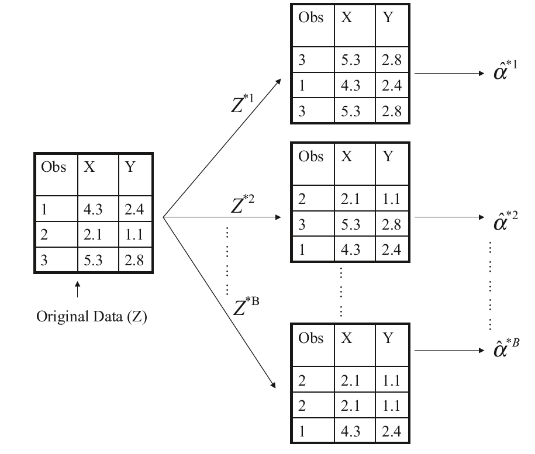

위 그림은 관찰값이 3개 있을 경우 bootstrap 방법에 대해 나타낸다.

3개의 관찰값을 중복 허용의 랜덤 샘플링하여 3개를 뽑아 새로운 데이터셋을 만들고 이를 이용하여 모수를 추정한다.

모수 $\alpha$에 대한 추정치는 각 bootstrap 단계인 $Z^{*r}$마다 계산할 수 있다. 이를 $\hat \alpha^{*r}$라 하자.

Bootstrap 방법에 의한 $\alpha$의 추정량의 표준오차는 다음으로 추정한다.

$$\mathrm{SE}_B (\hat \alpha) = \sqrt{\frac{1}{B-1} \sum_{r=1}^{B} \left( \hat \alpha^{*r} - \overline{ \hat \alpha^{*}} \right)^2}$$